# Estudios de Informática, Multimedia y Telecomunicaciones

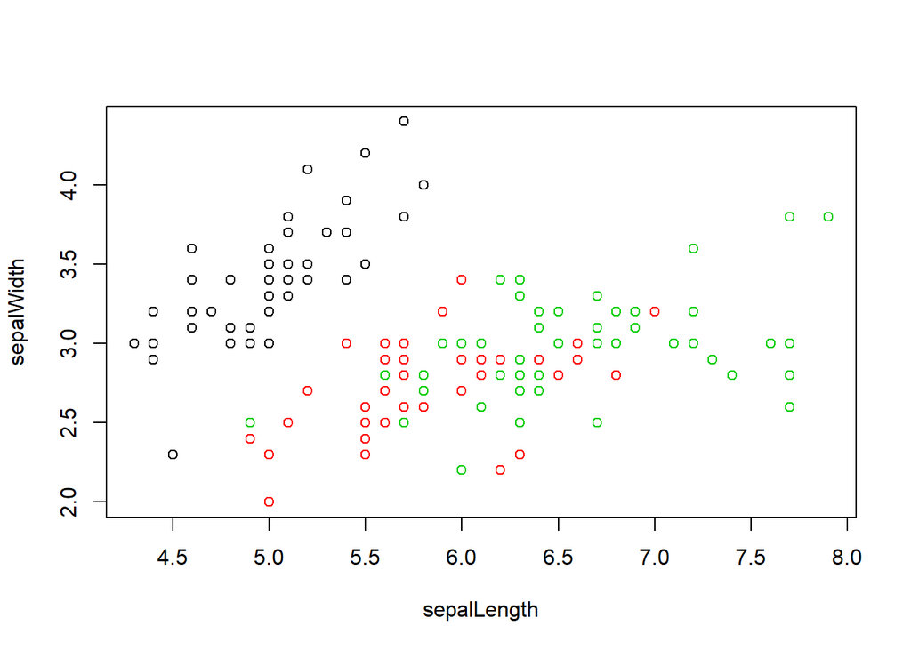

```r
plot(x[c(1,2)], col=iris_data$class)
```

Podemos observar que el sépalo no es un buen indicador para diferenciar a las tres subespecies, no con la metodología de kmeans, dado que dos de las subespecies estan demasiado mezcladas para poder diferenciar nada.

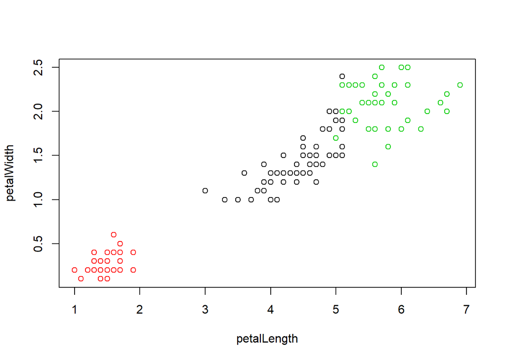

```r
# petalLength y petalWidth
plot(x[c(3,4)], col=iris3clusters$cluster)
```

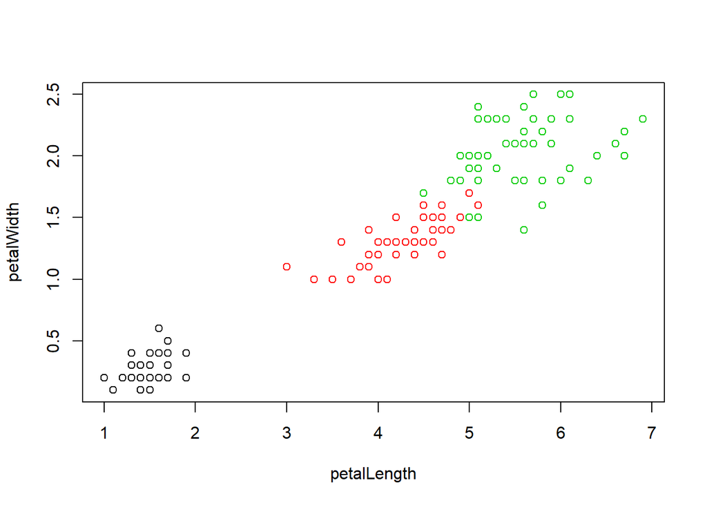

```r
plot(x[c(3,4)], col=iris_data$class)
```

Una buena técnica que ayuda a entender los grupos que se han formado, es mirar de darles un nombre. Cómo por ejemplo:

Esto nos ayuda a entender cómo están formados los grupos y a referirnos a ellos en análisis posteriores.

Una última cosa que nos queda por hacer, es saber cuales de las muestras iniciales han sido mal clasificadas y cómo. Eso lo conseguimos con el siguiente comando.

```r
table(iris3clusters$cluster,iris_data$class)
```

```
##
##     Iris-setosa Iris-versicolor Iris-virginica
##   1           0              48             14
##   2          49               0              0
##   3           0               2             36
```

Y así, podemos sacar un porcentaje de precisión del modelo

```r
100*(36 + 48 + 49)/(133+(2+14))
```

```
## [1] 89.26174
```

## 3.2 Ejercicio 1.1

Tomando como punto de partida los ejemplos mostrados, realizar un estudio similar con otro conjunto de datos. Pueden ser datos reales de vuestro ámbito laboral o de algún repositorio de datos de Internet. Mirad por ejemplo: http://www.ics.uci.edu/~mlearn/MLSummary.html.

A la hora de elegir la base de datos ten en cuenta que sea apropiada para problemas no supervisados y que los atributos sean también apropiados para su uso con el algoritmo kmeans.

No hay que olvidarse de la fase de preparación y análisis de datos.

### 3.2.1 Respuesta 1.1:

Hemos elegido el dataset https://www.kaggle.com/vjchoudhary7/customer-segmentation-tutorial-in-python para clasificación de clientes de un centro comercial, posee variables categóricas y variables numéricas.

```r
customers_data<-read.csv("Mall_Customers.csv", header=T, sep=",")
attach(customers_data)
colnames(customers_data) <- c("CustomerID", "Gender", "Age", "AnnualIncome", "SpendingScore")
summary(customers_data)
```

```
##    CustomerID        Gender         Age         AnnualIncome    SpendingScore
##  Min.   :  1.00   Female:112   Min.   :18.00   Min.   : 15.00   Min.   : 1.00
##  1st Qu.: 50.75   Male  : 88   1st Qu.:28.75   1st Qu.: 41.50   1st Qu.:34.75
##  Median :100.50                Median :36.00   Median : 61.50   Median :50.00
##  Mean   :100.50                Mean   :38.85   Mean   : 60.56   Mean   :50.20
##  3rd Qu.:150.25                3rd Qu.:49.00   3rd Qu.: 78.00   3rd Qu.:73.00
##  Max.   :200.00                Max.   :70.00   Max.   :137.00   Max.   :99.00
```

Comprobamos valores nulos. No hay ninguno, el dataset parece estar ya tratado.

```r
colSums(is.na(customers_data))
```

```
##    CustomerID        Gender           Age  AnnualIncome SpendingScore
##             0             0             0             0             0
```

```r
colSums(customers_data==" ")
```

```
##    CustomerID        Gender           Age  AnnualIncome SpendingScore
##             0             0             0             0             0
```

```r
colSums(customers_data==0)#Dada la naturaleza de los atributos, aquí el 0 no es un valor admisible, por ello lo busco para asegurarme de que no hay ningún valor numérico nulo
```

```
##    CustomerID        Gender           Age  AnnualIncome SpendingScore
##             0             0             0             0             0
```

Customer ID no es relevante para el modelo, no nos aponta ninguna información así que lo quitamos, tampoco gender por ser un atributo categórico.

```r
x<-customers_data[,3:5]
str(x)
```

```
## 'data.frame':    200 obs. of  3 variables:
##  $ Age          : int  19 21 20 23 31 22 35 23 64 30 ...
##  $ AnnualIncome : int  15 15 16 16 17 17 18 18 19 19 ...
##  $ SpendingScore: int  39 81 6 77 40 76 6 94 3 72 ...
```

Normalizamos

```r
x = (x-min(x))/(max(x)-min(x))
```

Aplicamos el algoritmo kmeans, como desconocemos el número de clusters idóneo probamos con múltimples, según la fuente, el valor idóneo está en 5 clusters.

```r
d <- daisy(x)
resultados <- rep(0, 10)
for (i in c(2,3,4,5,6,7,8,9,10))
{
  fit           <- kmeans(x, i)
  y_cluster     <- fit$cluster
  sk            <- silhouette(y_cluster, d)
  resultados[i] <- mean(sk[,3])
}
```

Posteriormente mostramos los valores de la silueta media para determinar qué número de clusters es el más adecuado.

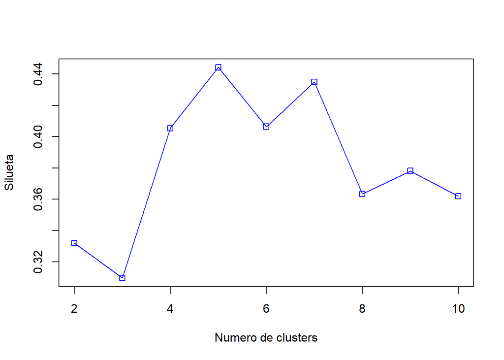

```r
plot(2:10,resultados[2:10],type="o",col="blue",pch=0,xlab="Numero de clusters",ylab="Silueta")
```

Comprobamos lo mismo aplicando como criterio el método elbow

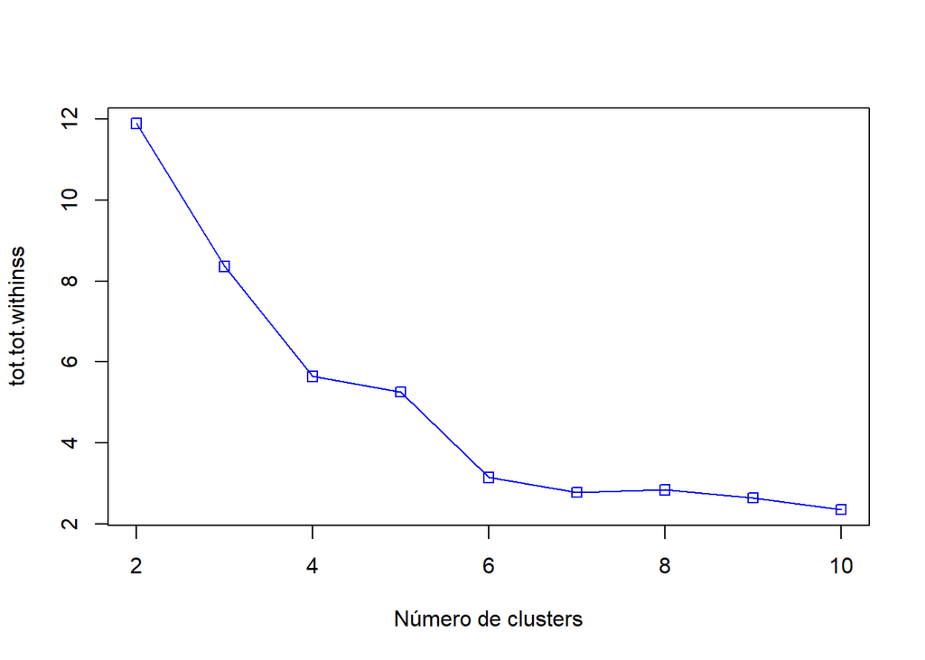

```r
resultados <- rep(0, 10)
for (i in c(2,3,4,5,6,7,8,9,10))
{
  fit           <- kmeans(x, i)
  resultados[i] <- fit$tot.withinss
}
plot(2:10,resultados[2:10],type="o",col="blue",pch=0,xlab="Número de clusters",ylab="tot.tot.withinss")
```

Comprobamos también el valor del número de clústers que mejor funcione de acuerdo a el crtiterio de la silueta media (“asw”) y el de Calinski-Harabasz (“ch”).

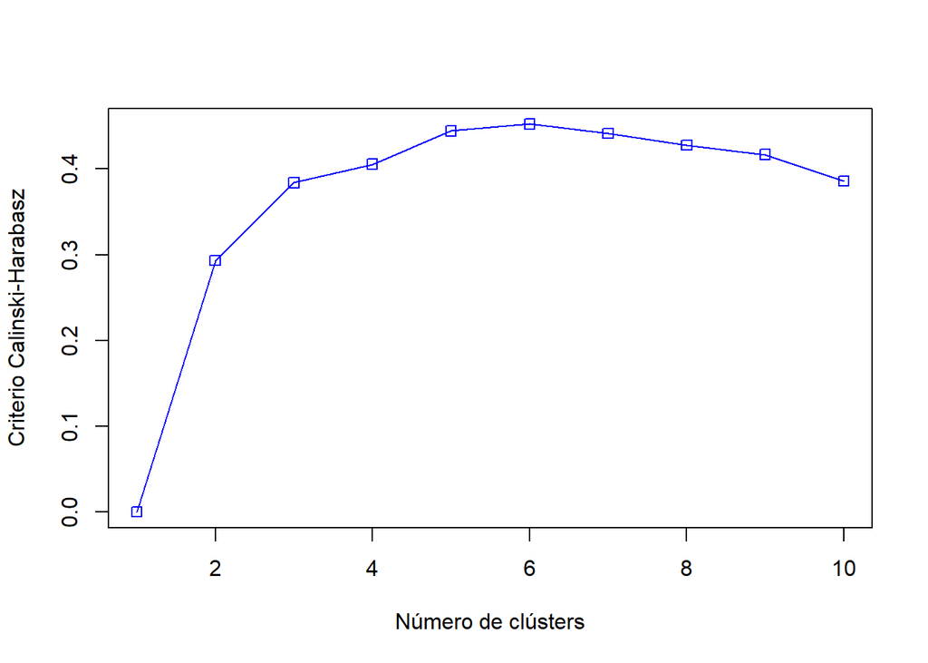

```r
library(fpc)
fit_ch  <- kmeansruns(x, krange = 1:10, criterion = "ch")
fit_asw <- kmeansruns(x, krange = 1:10, criterion = "asw")

#cat("silueta media: ",fit_asw$bestk)
plot(1:10,fit_asw$crit,type="o",col="blue",pch=0,xlab="Número de clústers",ylab="Criterio Calinski-Harabasz")
```

De nuevo el 5, aunque aquí el 6 le supera por poco.

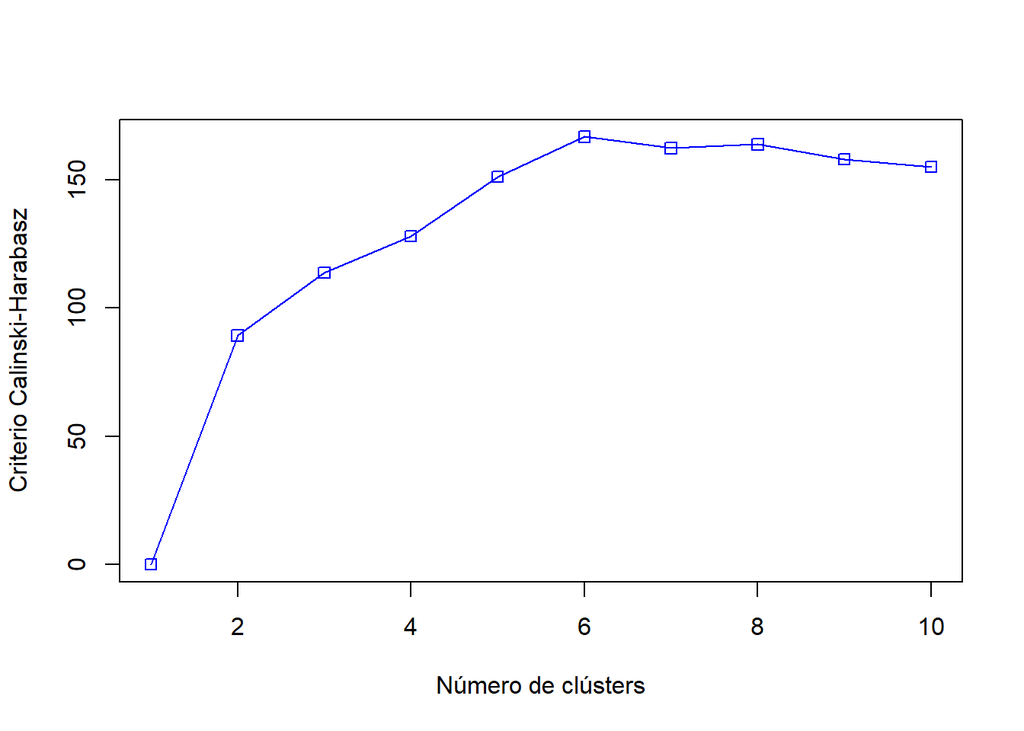

```r
#cat("Calinski-Harabasz ",fit_ch$bestk)
plot(1:10,fit_ch$crit,type="o",col="blue",pch=0,xlab="Número de clústers",ylab="Criterio Calinski-Harabasz")
```

Esta última hace dudar de si 5 es el valor adecuado, parece que 6 también es candidatos a ser le valor del número de clusters.

Como se puede observar, el número de clusters más viables son 5 o 6, pero no está claro. Comprobamos ambos para ver si alguno de los resultados nos satisface.

Para 5 clusters:

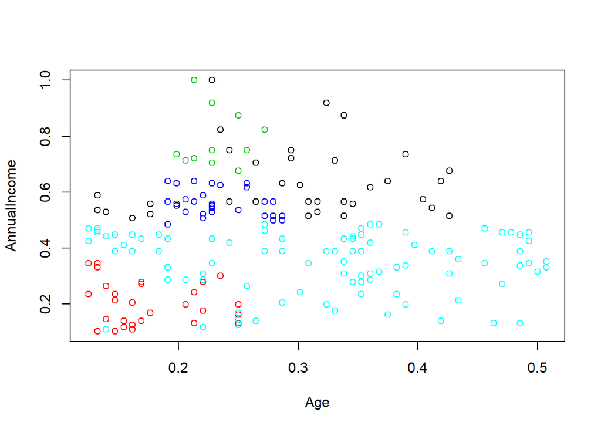

```r
customers5clusters <- kmeans(x, 5)
# Annual Income y Age
plot(x[c(1,2)], col=customers5clusters$cluster)
```

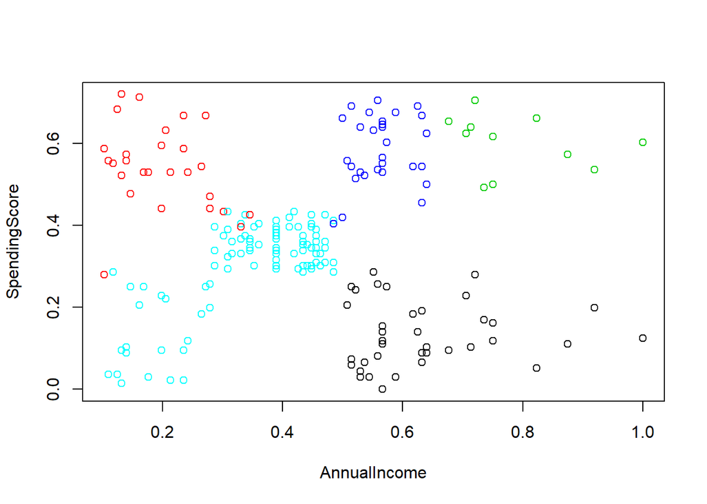

```r
# SpendingScore y AnnualIncome
plot(x[c(2,3)], col=customers5clusters$cluster)
```

Para 6 clusters:

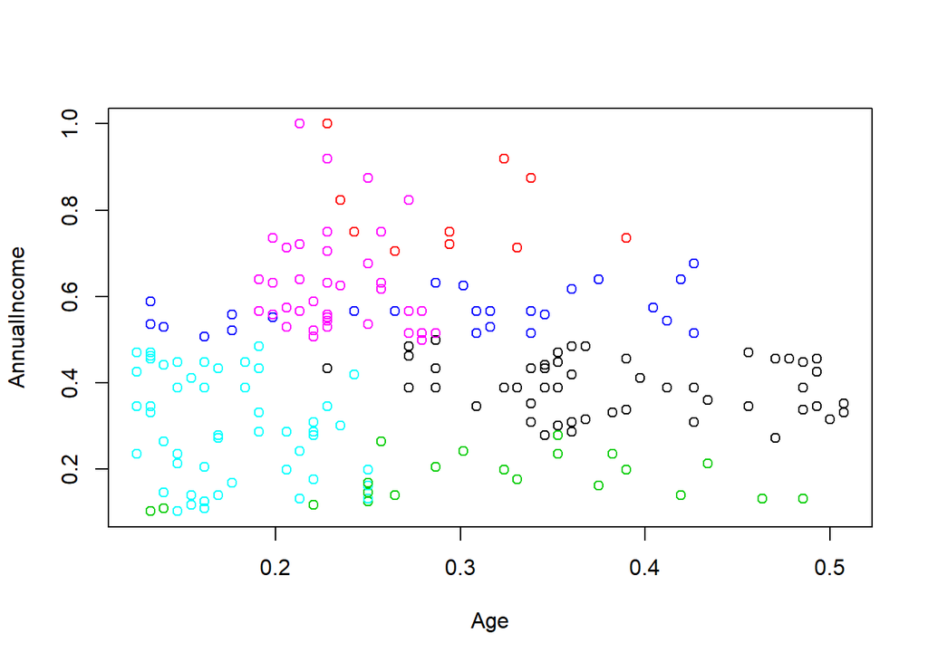

```r
customers6clusters <- kmeans(x, 6)
# AnnualIncome y Age
plot(x[c(1,2)], col=customers6clusters$cluster)
```

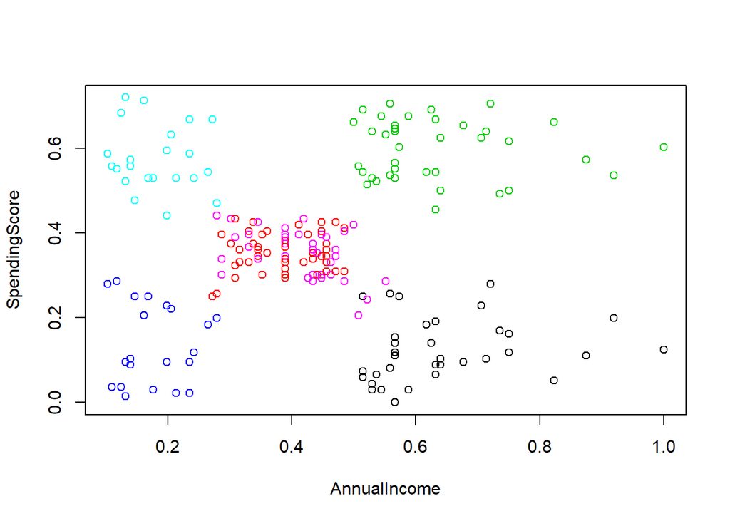

```r
customers6clusters <- kmeans(x, 6)
# SpendingScore y AnnualIncome
plot(x[c(2,3)], col=customers6clusters$cluster)
```

Ahora vamos a evaluar la calidad del proceso de agregación. Para ello usaremos la función silhouette que calcula la silueta de cada muestra

```r
d  <- daisy(x)
sk5 <- silhouette(customers5clusters$cluster, d)
sk6 <- silhouette(customers6clusters$cluster, d)
aux7 <- kmeans(x, 7)
sk7 <- silhouette(aux7$cluster, d)
aux4 <- kmeans(x, 4)
sk4 <- silhouette(aux4$cluster, d)
```

```r
# con 5
mean(sk5[,3])
```

```
## [1] 0.3643836
```

```r
#con 6
mean(sk6[,3])
```

```
## [1] 0.4523444
```

```r
#con 7
mean(sk7[,3])
```

```
## [1] 0.435071
```

```r
#con 4
mean(sk4[,3])
```

```
## [1] 0.3923603
```

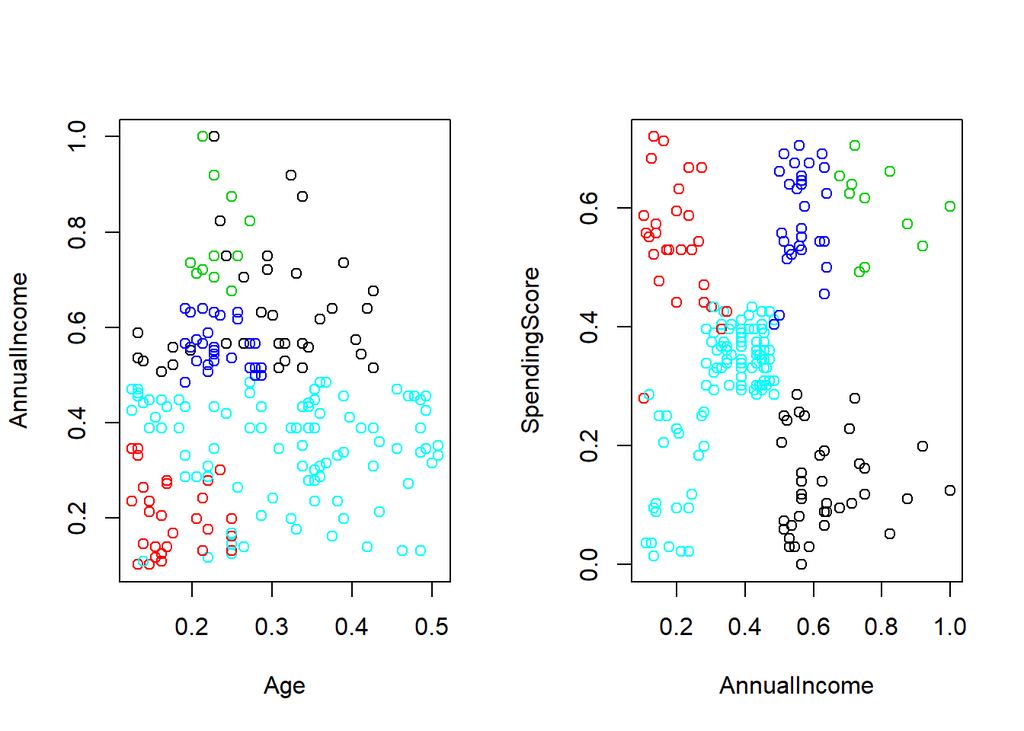

```r
par(mfcol=c(1,2))
plot(x[c(1,2)], col=customers5clusters$cluster)
plot(x[c(2,3)], col=customers5clusters$cluster)
```

## 3.3 Ejercicio 1.2

Buscar información sobre otros métodos de agregación diferentes al Kmeans. Partiendo del ejercicio anterior probar el funcionamiento de al menos 2 métodos diferentes y comparar los resultados obtenidos.

### 3.3.1 Respuesta 1.2

- Hierarchical Clustering: Este método realiza clustering no supervisado, se diferencia del kmeans en que no es necesario indicar el número de clusters, el propio algoritmo lo indica. El algoritmo selecciona cada dato como un centroide y lo agrupa con el centroide más cercano según la distancia euclídea, formando un nuevo cluster.

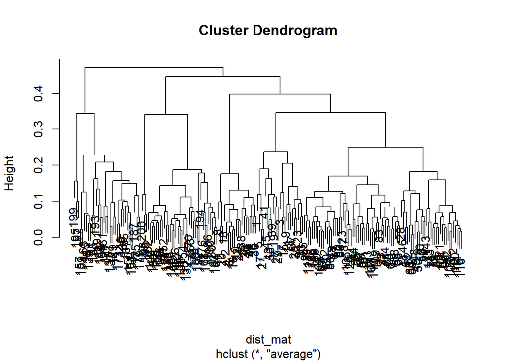

```r
dist_mat <- dist(x, method = 'euclidean')#distancia euclidea entre todos los puntos
hclust_avg <- hclust(dist_mat, method = 'average')
plot(hclust_avg)#dendograma que muestra la jerarquía de clusters
```

Como hemos decidido que son 5 los cluster que queremos, podemos visualizar el árbol con dicho nivel de agregación.

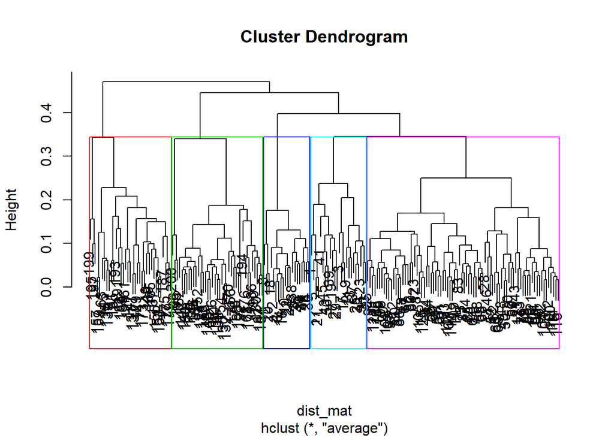

```r
cut_avg <- cutree(hclust_avg, k = 5)#cortamos el arbol para ver los clusters
plot(hclust_avg)
rect.hclust(hclust_avg , k = 5, border = 2:6)
abline(h = 3, col = 'red')
```

Ploteamos en función de AnnualIncome y SpendingScore paara comparar con el k-means

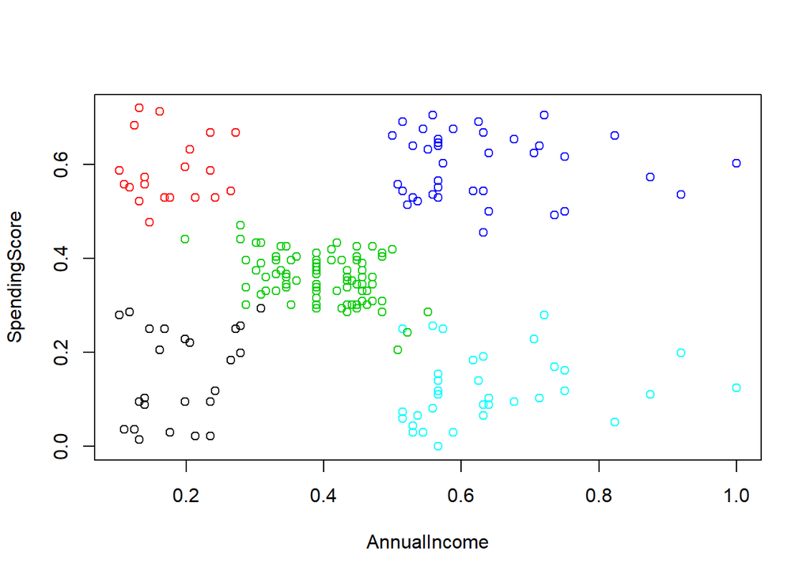

```r
suppressPackageStartupMessages(library(dplyr))
x_cl <- mutate(x, cluster = cut_avg)
plot(x[c(2,3)], col=x_cl$cluster)
```

Respecto al kmeans, varia en:

```r
table(x_cl$cluster,customers5clusters$cluster)
```

```
##
##      1  2  3  4  5
##   1  0  1  0  0 23
##   2  0 20  0  0  0
##   3  3  7  0  2 70
##   4  0  0 11 28  0
##   5 35  0  0  0  0
```

- Density Based Clustering (DBSCAN): es un método no supervisado que, a diferencia del kmeans o del Hierarchical, funciona en situaciones de ruido, también funciona sin necesidad de indicar el número de clusters. Al contrario que en los anteriores, DSCAN utiliza la densidad de los datos para determinar los clusters y no la distancia euclídea. Las reglas del algoritmo son:
  - Un punto p es un punto núcleo si al menos minPts puntos están a una distancia ε de él y, esos puntos son directamente alcanzables desde p. No es posible tener puntos directamente alcanzables desde un punto que no sea un núcleo.
  - Un punto q es alcanzable desde p si existe una secuencia de puntos p1,…,pn donde p1=p y pn=q tal que cada punto pi+1 es directamente alcanzable desde pi; es decir, todos los puntos de la secuencia deben ser puntos núcleos, con la posible excepción de q.
  - Un punto que no sea alcanzable desde cualquier otro punto es considerado ruido.

```r
library(dbscan)
db<-dbscan(x, eps = 0.08)
db
```

```
## DBSCAN clustering for 200 objects.
## Parameters: eps = 0.08, minPts = 5
## The clustering contains 5 cluster(s) and 56 noise points.
##
##  0  1  2  3  4  5
## 56 17  5 80 32 10
##
## Available fields: cluster, eps, minPts
```

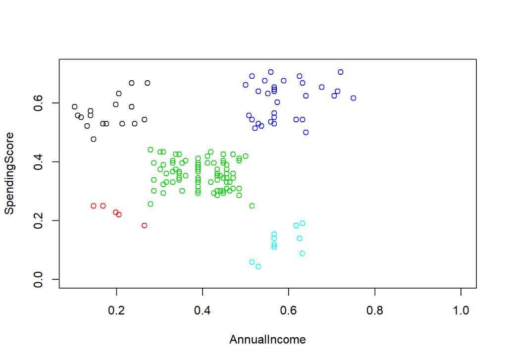

```r
plot(x[c(2,3)], col=db$cluster)
```

Los parámetros del método pueden no ser los más óptimos aunque han sido elegidos mediante los criterios de la documentación. Como podemos ver, este método no funciona bien para este ejercicio, esto es debido a que, pese a que la implementación pudiera ser mejor, el método está pensado para aislar ruido de clusters con gran desidad de puntos. Es cierto que lo hace de forma excelente en el grupo del centro, pero de ninguna manera, este método detectaría los puntos que faltan a la derecha de la figura, pues la densidad en esas zonas es demasiado baja.